# DM_HW1

Youfei Zhang

## Question 1: L2 linear regression

Implement L2 regularized linear regression algorithm with lambda ranging from 0 to 150 (integers only). For each of the 6 dataset, plot both the training set MSE and the test set MSE as a function of lambda (x-axis) in one graph.

```r
## prepare packages
require(knitr)
require(glmnet)
library(dplyr)
library(tidyr)
## standardize scientific notations
options(scipen = 999)

## define lambda
lambdas = (seq(0:150))
```

for dataset 1: train-100-10.csv, test-100-10.csv:

```r
## set up working directory
setwd("/Users/Scarlet/Desktop/code/CISC6930_DM/hw/hw1")

## prepare data
train1 = read.csv(file = "/Users/Scarlet/Desktop/code/CISC6930_DM/hw/hw1/train-100-10.csv", sep = ",")
test1 = read.csv(file = "/Users/Scarlet/Desktop/code/CISC6930_DM/hw/hw1/test-100-10.csv", sep = ",")
```

```r
## define features and response for training and testing sets
x.train1 = model.matrix(y~.-1, data = train1)
y.train1 = train1$y
x.test1 = model.matrix(y~.-1, data = test1)
y.test1 = test1$y
```

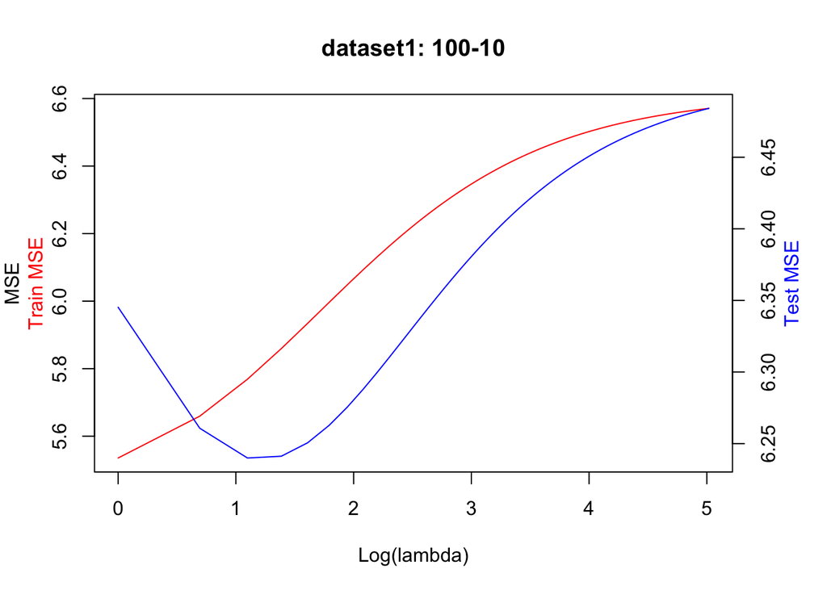

```r
## define the range of lambdas
lambdas = (seq(0:150))

## train ridge model on train-100-10 data with alpha = 0
fit.ridge1 = glmnet(x.train1, y.train1, alpha = 0, lambda = lambdas)

## train the model on training data to compute training MSE
pred.tr1 = predict(fit.ridge1, x.train1)
mse.tr1 = apply((pred.tr1 - y.train1)^2, 2, mean) # column-wised

## train the model on testing data to compute testing MSE
pred.test1 = predict(fit.ridge1, x.test1)
mse.test1 = apply((y.test1 - pred.test1)^2, 2, mean)

## plot training and testing MSE as a function of lambda
par(mar = c(5,4,4,4))
plot(log(fit.ridge1$lambda), mse.tr1, type = "l", col = "red", xlab = "Log(lambda)", ylab = "MSE", main = "dataset1: 100-10")
mtext("Train MSE",side = 2,line = 2,col = 2)
par(new = TRUE)
plot(log(fit.ridge1$lambda), mse.test1, type = 'l', axes = F, col = "blue", xlab = " ", ylab = " ")
axis(side = 4)
mtext("Test MSE",side = 4,line = 2,col = 4)
```

for dataset 2: train-100-100.csv, test-100-100.csv

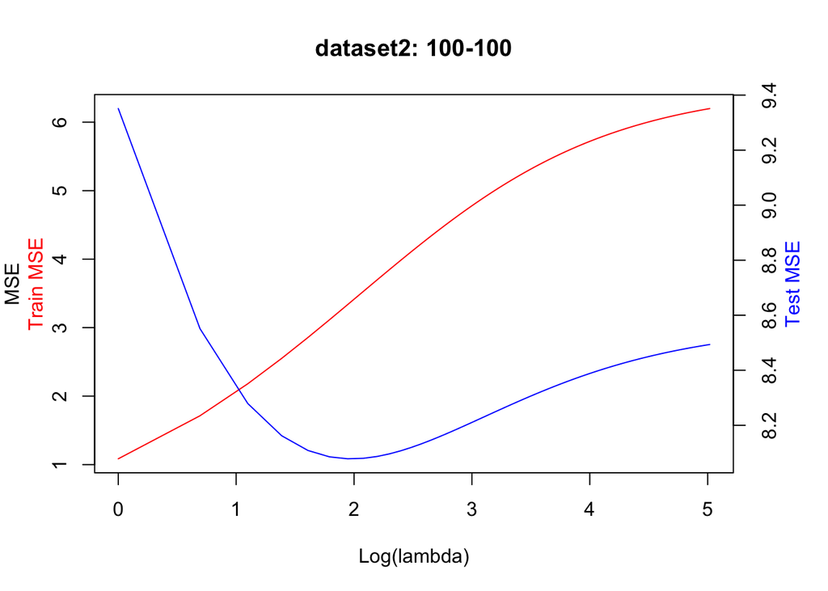

```r
## repeat the same steps for dataset 2: 100-100
train2 = read.csv('/Users/Scarlet/Desktop/code/CISC6930_DM/hw/hw1/train-100-100.csv', header = TRUE, sep = ",")
test2 = read.csv("/Users/Scarlet/Desktop/code/CISC6930_DM/hw/hw1/test-100-100.csv", header = TRUE, sep = ",")

x.train2 = model.matrix(y~.-1, data = train2)
y.train2 = train2$y
x.test2 = model.matrix(y~.-1, data = test2)
y.test2 = test2$y

lambdas = (seq(0:150))
fit.ridge2 = glmnet(x.train2, y.train2, alpha = 0, lambda = lambdas)

pred.tr2 = predict(fit.ridge2, x.train2)
mse.tr2 = apply((pred.tr2 - y.train2)^2, 2, mean) # column-wised

pred.test2 = predict(fit.ridge2, x.test2)
mse.test2 = apply((y.test2 - pred.test2)^2, 2, mean)

par(mar = c(5,4,4,4))
plot(log(fit.ridge2$lambda), mse.tr2, type = "l", col = "red", xlab = "Log(lambda)", ylab = "MSE", main = "dataset2: 100-100")
mtext("Train MSE",side = 2,line = 2,col = 2)
par(new = TRUE)
plot(log(fit.ridge2$lambda), mse.test2, type = 'l', axes = F, col = "blue", xlab = " ", ylab = " ")
axis(side = 4)
mtext("Test MSE",side = 4,line = 2,col = 4)
```

for dataset 3: train-1000-100.csv, test-1000-100.csv

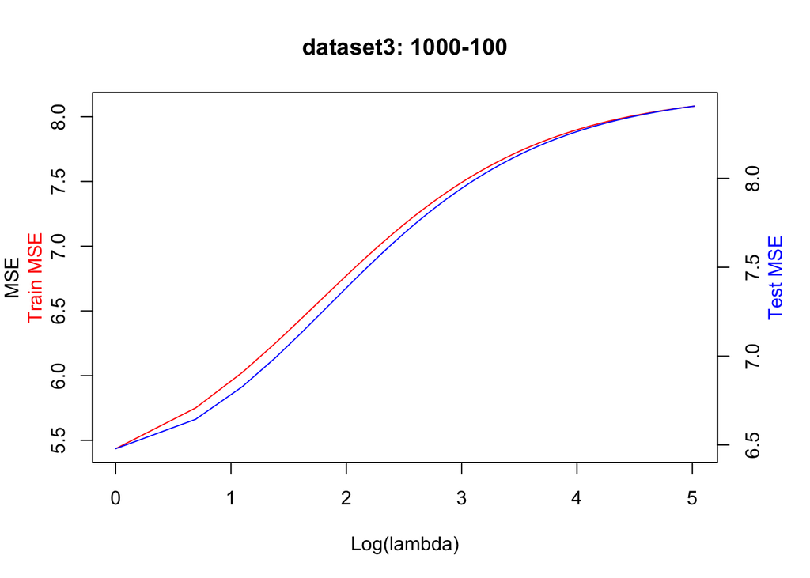

```r
## repeat the same steps for dataset 3: 1000-100
train3 = read.csv('/Users/Scarlet/Desktop/code/CISC6930_DM/hw/hw1/train-1000-100.csv', header = TRUE, sep = ",")
test3 = read.csv('/Users/Scarlet/Desktop/code/CISC6930_DM/hw/hw1/test-1000-100.csv', header = TRUE, sep = ",")

x.train3 = model.matrix(y~.-1, data = train3)
y.train3 = train3$y
x.test3 = model.matrix(y~.-1, data = test3)
y.test3 = test3$y

lambdas = (seq(0:150))
fit.ridge3 = glmnet(x.train3, y.train3, alpha = 0, lambda = lambdas)

pred.tr3 = predict(fit.ridge3, x.train3)
mse.tr3 = apply((pred.tr3 - y.train3)^2, 2, mean) # column-wised

pred.test3 = predict(fit.ridge3, x.test3)
mse.test3 = apply((y.test3 - pred.test3)^2, 2, mean)

par(mar = c(5,4,4,4))
plot(log(fit.ridge3$lambda), mse.tr3, type = "l", col = "red", xlab = "Log(lambda)", ylab = "MSE", main = "dataset3: 1000-100")
mtext("Train MSE",side = 2,line = 2,col = 2)
par(new = TRUE)
plot(log(fit.ridge3$lambda), mse.test3, type = 'l', axes = F, col = "blue", xlab = " ", ylab = " ")
axis(side = 4)
mtext("Test MSE",side = 4,line = 2,col = 4)
```

Taking the first 50, 100, and 150 instances of 1000-100

```r
## for train-1000-100.csv:
## taking the first 50, 100, and 150 instances
train3_50 = train3[0:50,]
train3_100 = train3[0:100,]
train3_150 = train3[0:150,]
```

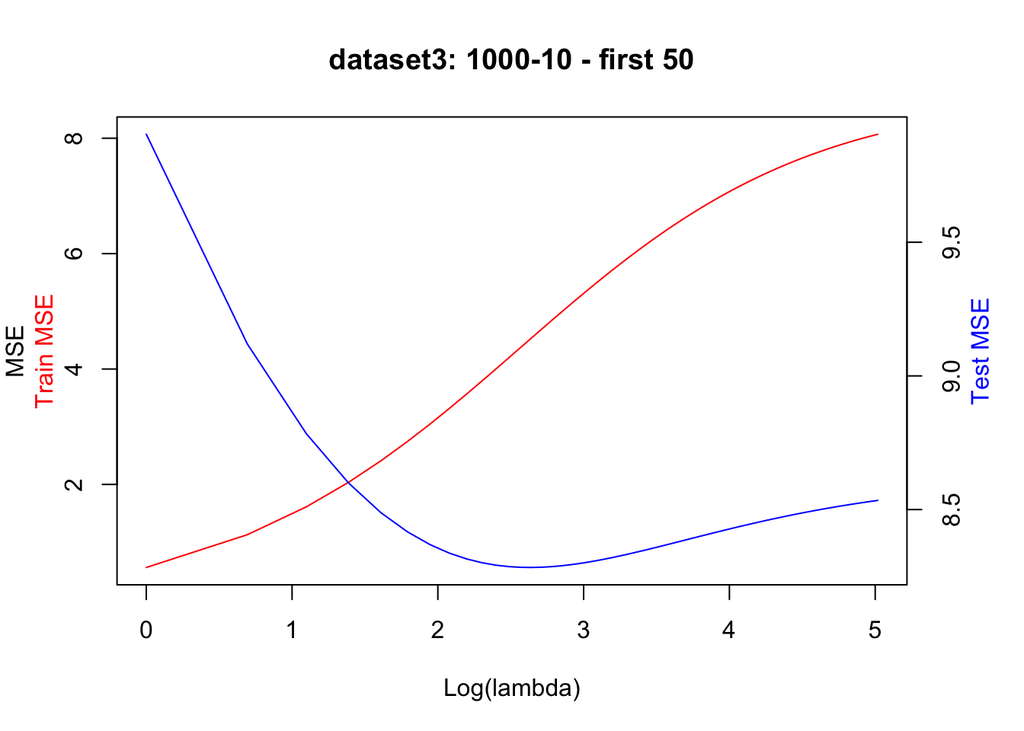

```r
## for dataset 3: 50 instances

x.train3_50 = model.matrix(y~.-1, data = train3_50)
y.train3_50 = train3_50$y

fit.ridge3_50 = glmnet(x.train3_50, y.train3_50, alpha = 0, lambda = lambdas)

pred.tr3_50 = predict(fit.ridge3_50, x.train3_50)
mse.tr3_50 = apply((pred.tr3_50 - y.train3_50)^2, 2, mean)

pred.test3_50 = predict(fit.ridge3_50, x.test3)
mse.test3_50 = apply((pred.test3_50 - y.test3)^2, 2, mean)

par(mar = c(5,4,4,4))
plot(log(fit.ridge3_50$lambda), mse.tr3_50, type = "l", col = "red", xlab = "Log(lambda)", ylab = "MSE", main = "dataset3: 1000-10 - first 50")
mtext("Train MSE",side = 2,line = 2,col = 2)
par(new = TRUE)
plot(log(fit.ridge3_50$lambda), mse.test3_50, type = 'l', axes = F, col = "blue", xlab = " ", ylab = " ")
axis(side = 4)
mtext("Test MSE",side = 4,line = 2,col = 4)
```

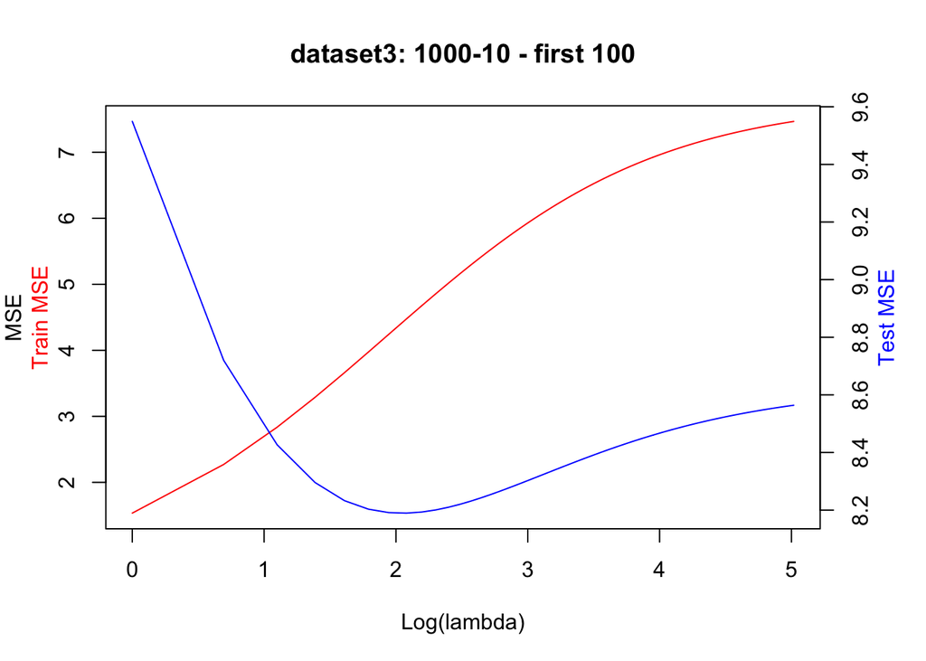

```r
## for dataset 3: 100 instances

x.train3_100 = model.matrix(y~.-1, data = train3_100)
y.train3_100 = train3_100$y

fit.ridge3_100 = glmnet(x.train3_100, y.train3_100, alpha = 0, lambda = lambdas)

pred.tr3_100 = predict(fit.ridge3_100, x.train3_100)
mse.tr3_100 = apply((pred.tr3_100 - y.train3_100)^2, 2, mean)

pred.test3_100 = predict(fit.ridge3_100, x.test3)
mse.test3_100 = apply((pred.test3_100 - y.test3)^2, 2, mean)

par(mar = c(5,4,4,4))
plot(log(fit.ridge3_100$lambda), mse.tr3_100, type = "l", col = "red", xlab = "Log(lambda)", ylab = "MSE", main = "dataset3: 1000-10 - first 100")
mtext("Train MSE",side = 2,line = 2,col = 2)
par(new = TRUE)
plot(log(fit.ridge3_100$lambda), mse.test3_100, type = 'l', axes = F, col = "blue", xlab = " ", ylab = " ")
axis(side = 4)
mtext("Test MSE",side = 4,line = 2,col = 4)
```

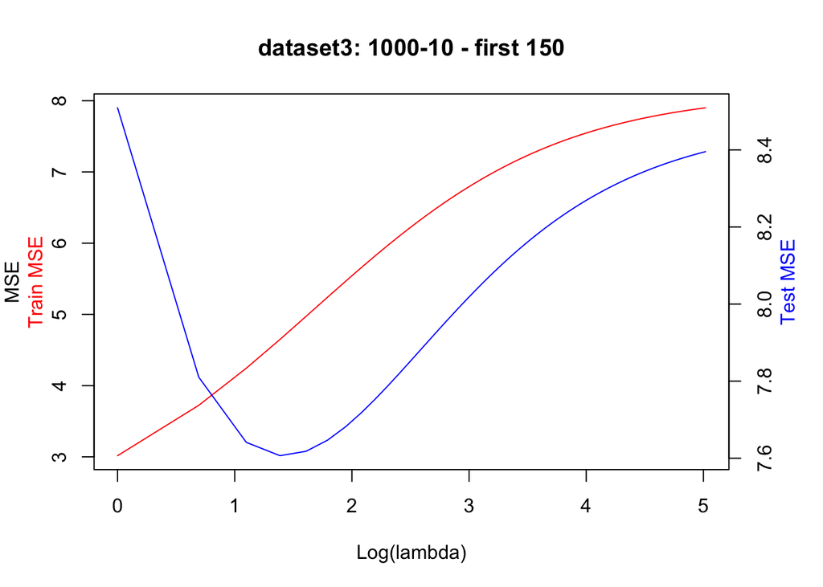

```r
## for dataset 3: 150 instances

x.train3_150 = model.matrix(y~.-1, data = train3_150)
y.train3_150 = train3_150$y

fit.ridge3_150 = glmnet(x.train3_150, y.train3_150, alpha = 0, lambda = lambdas)

pred.tr3_150 = predict(fit.ridge3_150, x.train3_150)
mse.tr3_150 = apply((pred.tr3_150 - y.train3_150)^2, 2, mean)

pred.test3_150 = predict(fit.ridge3_150, x.test3)
mse.test3_150 = apply((pred.test3_150 - y.test3)^2, 2, mean)

par(mar = c(5,4,4,4))
plot(log(fit.ridge3_150$lambda), mse.tr3_150, type = "l", col = "red", xlab = "Log(lambda)", ylab = "MSE", main = "dataset3: 1000-10 - first 150")
mtext("Train MSE",side = 2,line = 2,col = 2)
par(new = TRUE)
plot(log(fit.ridge3_150$lambda), mse.test3_150, type = 'l', axes = F, col = "blue", xlab = " ", ylab = " ")
axis(side = 4)
mtext("Test MSE",side = 4,line = 2,col = 4)
```

1. For each dataset, which lambda value gives the least test set MSE?

```r
## for dataset 1: train-100-10.csv, test-100-10.csv
opt_lambda_1 = fit.ridge1$lambda[order(mse.test1)[1]] ## put in ascending order
opt_lambda_1
```

```
## [1] 3
```

```r
# coef(fit.ridge1, s = opt_lambda_1)
```

Answer: lambda = 3 gives the least set MSE

```r
## for dataset 2: train-100-100.csv, test-100-100.csv
opt_lambda_2 = fit.ridge2$lambda[order(mse.test2)[1]]
opt_lambda_2
```

```
## [1] 7
```

```r
# coef(fit.ridge2, s = opt_lambda_2)
```

Answer: lambda = 7 gives the least set MSE

```r
## for dataset 3: train-1000-100.csv, test-1000-100.csv
opt_lambda_3 = fit.ridge3$lambda[order(mse.test3)[1]]
opt_lambda_3
```

```
## [1] 1
```

```r
# coef(fit.ridge3, s = opt_lambda_3)
```

Answer: lambda = 1 gives the least set MSE

```r
## for dataset 3: 50 instances
opt_lambda_3_50 = fit.ridge3_50$lambda[order(mse.test3_50)[1]]
opt_lambda_3_50
```

```
## [1] 14
```

```r
# coef(fit.ridge3_50, s = opt_lambda_3_50)
```

Answer: lambda = 14 gives the least set MSE

```r
opt_lambda_3_100 = fit.ridge3_100$lambda[order(mse.test3_100)[1]]
opt_lambda_3_100
```

```
## [1] 8
```

```r
# coef(fit.ridge3_100, s = opt_lambda_3_100)
```

Answer: lambda = 8 gives the least set MSE

```r
## for dataset 3: 150 instances
opt_lambda_3_150 = fit.ridge3_150$lambda[order(mse.test3_150)[1]]
opt_lambda_3_150
```

```
## [1] 4
```

```r
# coef(fit.ridge3_150, s = opt_lambda_3_150)
```

Answer: lambda = 4 gives the least set MSE

2. For each of datasets 100-100, 50(1000)-100, 100(1000)-100, provide an additional graph with lambda ranging from 1 to 150.

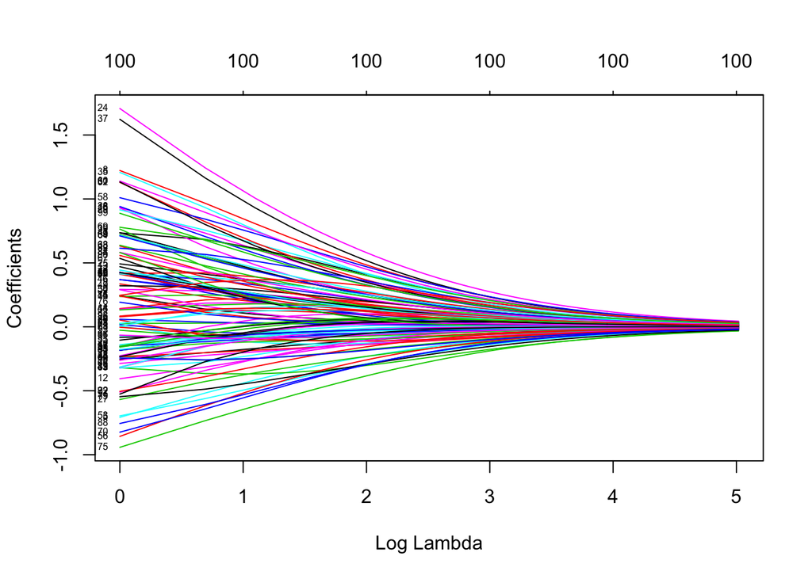

```r
## draw a plot of coefficients
# par(mfrow = c(3,1))

## for dataset2: 100-100
plot(fit.ridge2, xvar = "lambda", label = TRUE)
```

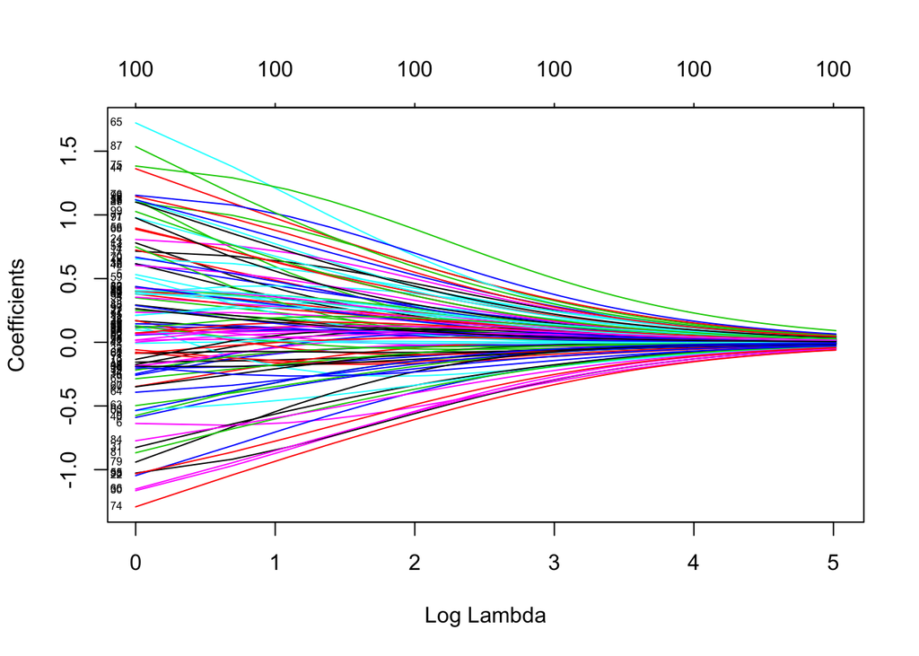

```r
## for dataset3: 50(1000)-100
plot(fit.ridge3_50, xvar = "lambda", label = TRUE)
```

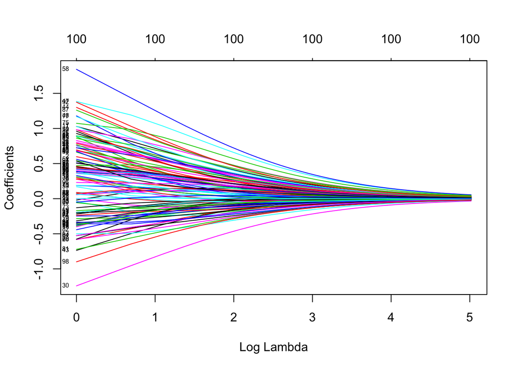

```r
## for dataset3: 100(1000)-100
plot(fit.ridge3_100, xvar = "lambda", label = TRUE)
```

3. Explain why lambda = 0 (i.e., no regularization) gives abnormally large MSEs for those three datasets in (b).

Answer: When lambda - 0, ridge regression is the same as a full ordinary least squares, all the parameters are fit into the model without any penality, which leads to the the largest MSE given its a full model.

## Question 2:

From the plots in question 1, we can tell which value of lambda is best for each dataset once we know the test data and its labels. This is not realistic in real world applications. In this part, we use cross validation (CV) to set the value for lambda. Implement the 10-fold CV technique discussed in class (pseudo code given in Appendix A) to select the best lambda value from the training set.

1. Using CV technique, what is the best choice of lambda value and the corresponding test set MSE for each of the six datasets?

```r
## set seed for reproducibility
set.seed(10)

## define lambda
lambdas = (seq(0:150))
```

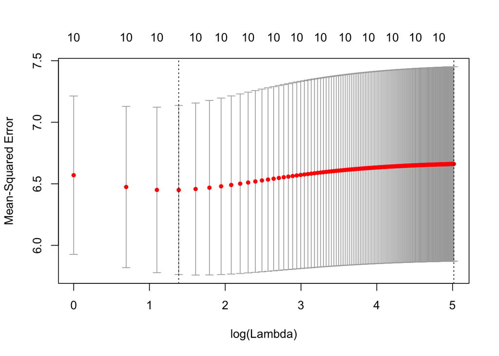

```r
## for dataset 1: train-100-10.csv, test-100-10.csv
cv.ridge1 = cv.glmnet(x.train1, y.train1, alpha = 0, lambda = lambdas)
plot(cv.ridge1)
```

```r
cv_opt_lambda1 = cv.ridge1$lambda.min
cv_opt_lambda1
```

```
## [1] 4
```

```r
cv.mse.min1 <- cv.ridge1$cvm[cv.ridge1$lambda == cv.ridge1$lambda.min]
cv.mse.min1
```

```
## [1] 6.449657
```

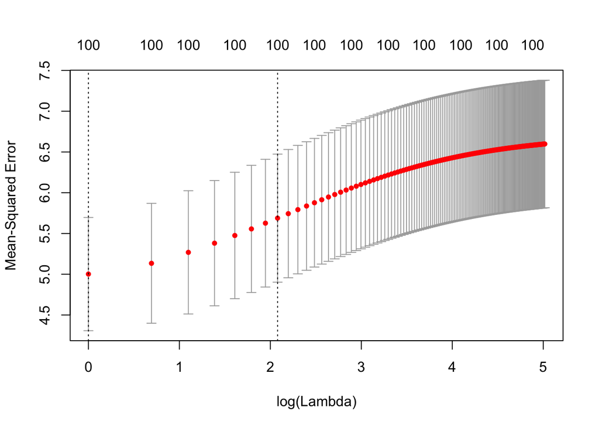

```r
## for dataset 2: train-100-100.csv, test-100-100.csv
cv.ridge2 = cv.glmnet(x.train2, y.train2, alpha = 0, lambda = lambdas)
plot(cv.ridge2)
```

```r
cv_opt_lambda2 = cv.ridge2$lambda.min
cv_opt_lambda2
```

```
## [1] 1
```

```r
cv.mse.min2 <- cv.ridge2$cvm[cv.ridge2$lambda == cv.ridge2$lambda.min]
cv.mse.min2
```

```
## [1] 5.002071
```

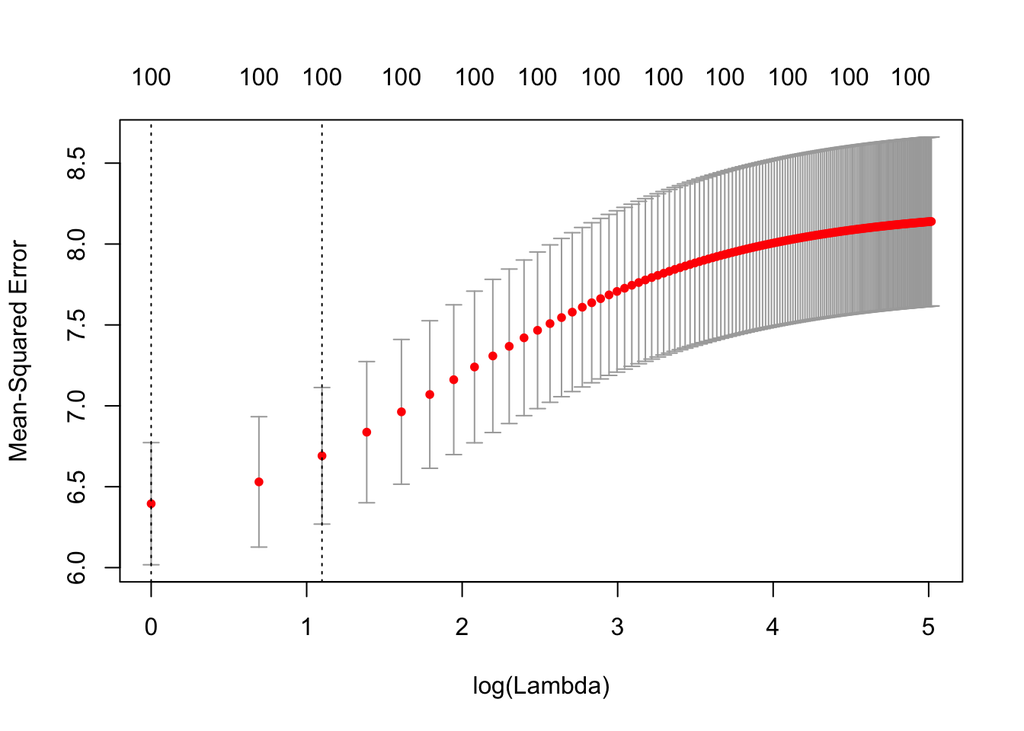

```r
## for dataset 3: train-1000-100.csv, test-1000-100.csv
cv.ridge3 = cv.glmnet(x.train3, y.train3, alpha = 0, lambda = lambdas)
plot(cv.ridge3)
```

```r
cv_opt_lambda3 = cv.ridge3$lambda.min
cv_opt_lambda3
```

```
## [1] 1
```

```r
cv.mse.min3 <- cv.ridge3$cvm[cv.ridge3$lambda == cv.ridge3$lambda.min]
cv.mse.min3
```

```
## [1] 6.395153
```

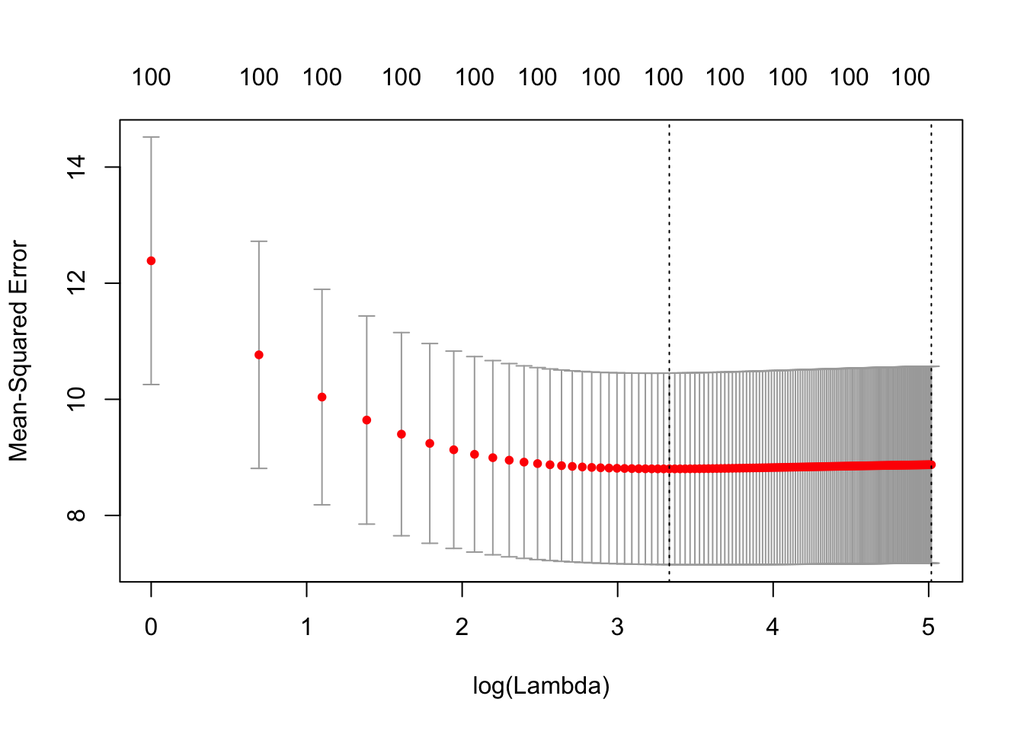

```r
## for dataset 3: 50 instances
cv.ridge3_50 = cv.glmnet(x.train3_50, y.train3_50, alpha = 0, lambda = lambdas)
plot(cv.ridge3_50)
```

```r
cv_opt_lambda3_50 = cv.ridge3_50$lambda.min
cv_opt_lambda3_50
```

```
## [1] 28
```

```r
cv.mse.min3_50 <- cv.ridge3_50$cvm[cv.ridge3_50$lambda == cv.ridge3_50$lambda.min]
cv.mse.min3_50
```

```
## [1] 8.801843
```

Answer: For dataset3_50, the best choice of lambda is 28, the corresponding test set MSE is 8.801843

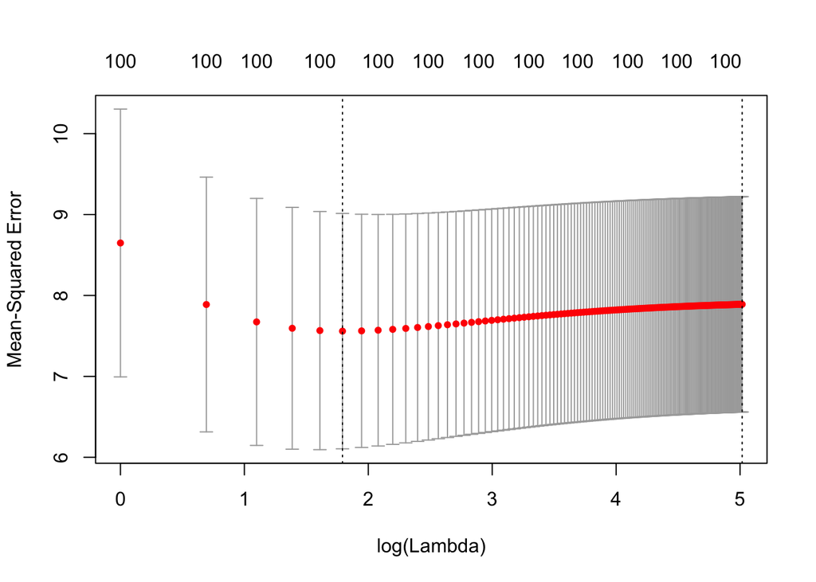

```r
## for dataset 3: 100 instances
cv.ridge3_100 = cv.glmnet(x.train3_100, y.train3_100, alpha = 0, lambda = lambdas)
plot(cv.ridge3_100)
```

```r
cv_opt_lambda3_100 = cv.ridge3_100$lambda.min
cv_opt_lambda3_100
```

```
## [1] 6
```

```r
cv.mse.min3_100 <- cv.ridge3_100$cvm[cv.ridge3_100$lambda == cv.ridge3_100$lambda.min]
cv.mse.min3_100
```

```
## [1] 7.559255
```

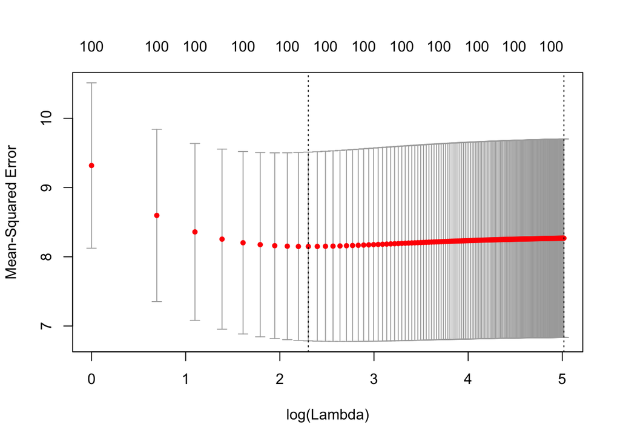

```r
## for dataset 3: 150 instances
cv.ridge3_150 = cv.glmnet(x.train3_150, y.train3_150, alpha = 0, lambda = lambdas)
plot(cv.ridge3_150)
```

```r
cv_opt_lambda3_150 = cv.ridge3_150$lambda.min
cv_opt_lambda3_150
```

```
## [1] 10
```

```r
cv.mse.min3_150 <- cv.ridge3_150$cvm[cv.ridge3_150$lambda == cv.ridge3_150$lambda.min]
cv.mse.min3_150
```

```
## [1] 8.148456
```

2. How do the values for lambda and MSE obtained from CV compare to the choice of lambda and MSE in question 1(a)?

Answer: The choice of lamda and MSE in question 1(a) is fixed, while the choice from CV varies everytime when we redo the CV. Sometimes the MSE obtained from CV is larger than the MSE in question 1(a) But overall, the choice of lambda and MSE obtained from CV is not too far away from the ones obtained in question 1(a)

3. What are the drawbacks of CV?

Answer: with CV, the data is seperated into training and validation set, which means the training data used to generate the model is smaller than the original dataset, only a subset of the observations are used to fit the model the test error from CV is highly variable, depends on which observations are included in the training set and which are included in the validation set the validation error may tend t overestimate the test error on the entire data set, given each training set is only a subset of the original training set

4. What are the factors afecting the performance of CV?

Answer: the number of folds that we choose  
the seperation of data: which observations are included in training and which are included in testing

## Question 3:

Fix lambda = 1, 25, 150. For each of these values, plot a learning curve for the algorithm using the dataset 1000-100.csv

```r
## prepare package
library(caret)
# define features and responses
x.train3 = model.matrix(y~.-1, data = train3)
y.train3 = train3$y
x.test3 = model.matrix(y~.-1, data = test3)
y.test3 = test3$y

# Run algorithms using 10-fold cross validation with 3 repeats
trainControl <- trainControl(method="repeatedcv", number = 10, repeats = 3)
metric <- "RMSE"
```

When lambda = 1

```r
# create empty data frame to store MSE
learnCurve1 <- data.frame(m = integer(21),
                         trainRMSE = integer(21),
                         testRMSE = integer(21))

for (i in 3:21){
  learnCurve1$m[i] <- i

  # train learning algorithm with size i
  fit.ridge <- train(y~., data = train3[1:i,], method = "glmnet", metric = metric, lambda = 1, tuneGrid = expand.grid(alpha = 0, lambda = 1), trControl=trainControl)
  learnCurve1$trainRMSE[i] <- fit.ridge$results$RMSE

  # use trained parameters to predict on test data
  prediction <- predict(fit.ridge, newdata = x.test3)
  rmse <- postResample(prediction, y.test3)
  learnCurve1$cvRMSE[i] <- rmse[1]
}
```

[output not shown]

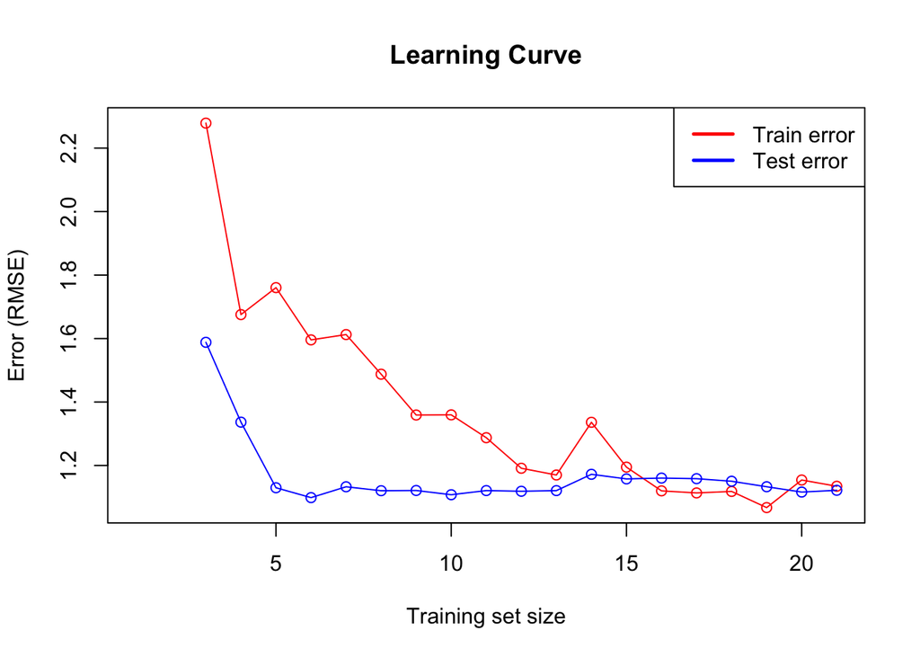

```r
# plot learning curves of training set size vs. error measure
# for training set and test set
plot(log(learnCurve1$trainRMSE),type = "o",col = "red", xlab = "Training set size",
     ylab = "Error (RMSE)", main = "Learning Curve")
lines(log(learnCurve1$cvRMSE), type = "o", col = "blue")
legend('topright', c("Train error", "Test error"), lty = c(1,1), lwd = c(2.5, 2.5),
       col = c("red", "blue"))
```

With lambda = 25

```r
learnCurve25 <- data.frame(m = integer(21),
                         trainRMSE = integer(21),
                         testRMSE = integer(21))

for (i in 3:21){
  learnCurve25$m[i] <- i

  # train learning algorithm with size i
  fit.ridge <- train(y~., data = train3[1:i,], method = "glmnet", metric = metric, lambda = 25, tuneGrid = expand.grid(alpha = 0, lambda = 25), trControl=trainControl)
  learnCurve25$trainRMSE[i] <- fit.ridge$results$RMSE

  # use trained parameters to predict on test data
  prediction <- predict(fit.ridge, newdata = x.test3)
  rmse <- postResample(prediction, y.test3)
  learnCurve25$cvRMSE[i] <- rmse[1]
}
```

[output not shown]

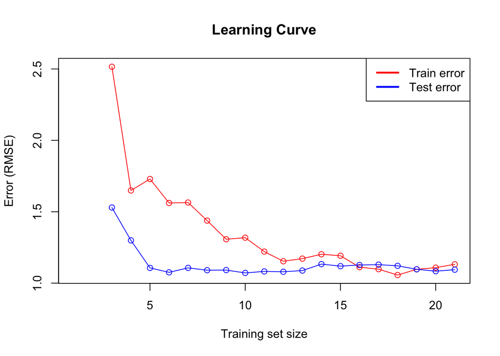

```r
# plot learning curves
plot(log(learnCurve25$trainRMSE),type = "o",col = "red", xlab = "Training set size", ylab = "Error (RMSE)", main = "Learning Curve")
lines(log(learnCurve25$cvRMSE), type = "o", col = "blue")
legend('topright', c("Train error", "Test error"), lty = c(1,1), lwd = c(2.5, 2.5),
       col = c("red", "blue"))
```

```r
learnCurve150 <- data.frame(m = integer(21),
                           trainRMSE = integer(21),
                           testRMSE = integer(21))

for (i in 3:21){
  learnCurve150$m[i] <- i

  # train learning algorithm with size i
  fit.ridge <- train(y~., data = train3[1:i,], method = "glmnet", metric = metric, lambda = 25, tuneGrid = expand.grid(alpha = 0, lambda = 25), trControl=trainControl)
  learnCurve150$trainRMSE[i] <- fit.ridge$results$RMSE

  # use trained parameters to predict on test data
  prediction <- predict(fit.ridge, newdata = x.test3)
  rmse <- postResample(prediction, y.test3)
  learnCurve150$cvRMSE[i] <- rmse[1]
}
```

[output not shown]

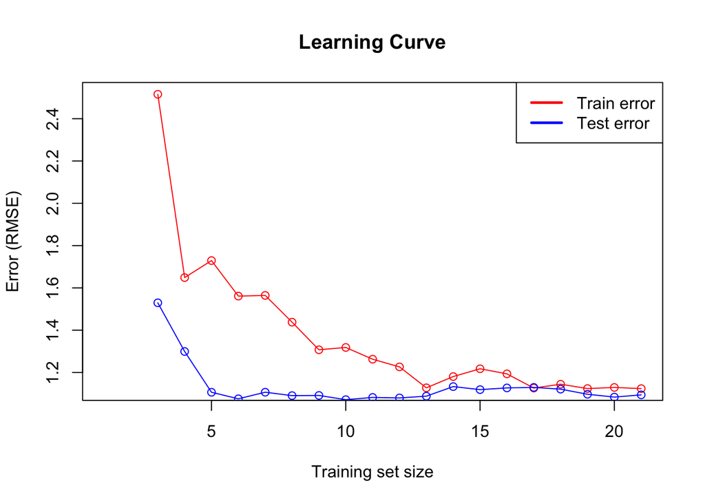

```r
# plot learning curves
plot(log(learnCurve150$trainRMSE),type = "o",col = "red", xlab = "Training set size",
     ylab = "Error (RMSE)", main = "Learning Curve")
lines(log(learnCurve150$cvRMSE), type = "o", col = "blue")
legend('topright', c("Train error", "Test error"), lty = c(1,1), lwd = c(2.5, 2.5),
       col = c("red", "blue"))
```